# Hotels in Pairs

## 1. Background Information

### 1.1 Data Context / Introduction to Hotel Reviews

The raw data is a dataset of 515k Hotel Reviews in Europe given by customers as well as ratings of 1493 luxury hotels extracted from the popular travel and lodging reservations website : Booking.com

###### How was this data created?

- The answer is through web scraping. Web scraping is the act of gathering specific data and copying it from the web into a database or spreadsheet for purposes of data analysis. To explain further, all of the information and variables in this dataset are located somewhere on the web page of reviews and is compiled into distinct columns of information. Jason Liu, a Kaggle enthusiast and current Data Analyst at Optiver trading firm is credited for creating this hotel data.

###### What is a hotel review anyway?

- Individuals that are planning their next ideal vacation really do need some advice, and in particular they would like to know what to expect when they begin their search for for accomodation. Because they have only seen pictures, heard briefly about a hotel they are considering, or simply heard propaganda coming from the hotel website itself, they would like to know from previous customers like themselves of specific details they mentioned during their stay and how it compared to their expectations.

###### How hotel reviews are written/verified through Booking.com?

It is possible to write hotel reviews on Booking.com through the following steps:

- (1) Booking a trip through Booking.com
- (2) Checking in at the property and completing your stay
- (3) A request from Booking.com asking guests about their stay. Through this method, authenticity of the guest’s stay is verified before adding a review to the website.

### 1.2 Discussion of Variable Information and Importance

The data contains 17 variables which describe information about the hotel and reviewer in some of the following ways.

- Background of the reviewer’s history on Booking.com / demographics
- Text of an individual’s review and other attributes related to their review
- Location details & a reviewer’s review history of hotels

###### Hotel Address

- This variable lists the exact location of the property and contains information such as the unit of the property, street name, city, country, and postal code.This is extracted through web scraping in which the address is provided under the name of the property on its main page.

###### Hotel Name

- This is very self-explanatory. The full name of a listing belongs in this variable

###### Lat((Latitude of hotel)

- The term latitude refers to the north-south position of a point on the surface of the earth. It is an angle measure that corresponds to 0° at the equator and 90° at the north and south poles. We indicated if a point is below or above the equator with S (South) or N (North).
- Example: Germany’s Berlin lies more east of the Prime Meridian than Holland’s Amsterdam. This is why Berlin is located at 13.4050° E, a greater numeric value than 4.9036° E for Amsterdam.

###### Review Date

- This is the date when the reviewer posted the review of the hotel. It gives the month, day, and year of the review.

###### Reviewer Score

- Based on one’s experience relating to value for money, service, cleanliness, and more, a score is assigned to their experience from 0 - 10.
- A higher score is reflective of a more positive experience, and a lower one indicative of a guest that may not want to stay there again.
- Booking.com notes that a rating between 7.0 - 8.0 is “Good”, one that is 8.0 - 9.0 (exclusive) is “Very Good”, and 9.0 inclusive - 10 is “Excellent”.

###### Average Score

- Average score (rating) of a hotel. This number will remain consistent across rows that pertain to the same property.

###### Days Since Review

- The number of days since review is the duration between the review date and the web scraping date of that review.
- The date of web scraping done by the author of this date was 8/3/2017. Example: Jaehyeong Lee rated a Booking.com property on 8/1/2017, two days before the scraping date. The value of “Days Since Review” is : 2.
- Booking.com only allows reviews 2 years old and newer to be factored into a hotel rating and displayed on the page. This is why the largest value for Days Since Review is at most 730 days.
- Reason: Reviews past 2 years may become obsolete and not reflect the overall rating a property now deserves.
- Example: The owner of a hotel changed in 2015, providing better service to its customers. By the year 2017, its old management is no longer reflective of the reputation of the hotel.

###### Reviewer Nationality

- The nationality of a reviewer describes the country that they are coming from / a citizen of. Our Data consists of hotels in Paris, France but the nationality of reviewers that traveled to this city are from so many countries in the world.

###### Total Number of Reviews

- This numeric variable indicates the number of valid reviews a property has on Booking.com during scraping.
- A hotel that has been in business since 2010 probably has more total reviews than one that opened in 2016.

###### Total Number of Reviews a Reviewer has Given

- Number of reviews that a reviewer has given in the past on Booking.com
- Reviewers that are well traveled and experienced with Booking.com may have more review counts.
- Example : Web scrapers look at hotel reviews and identify a review of an individual and they make a note of their total # of reviews for all hotels.

###### Negative Review / Review Total Negative Word Counts & Positive Review / Review Total Positive Word Counts

- Text of the negative review is noted in the Negative Review variable, positives are in the Positive Review variable.
- Total amount of words the reviewer wrote to express their negative / positive comment is listed in the corresponding negative / positive word count variable.
- If there was no negative / OR positive comment for an observational unit, the negative review variable will note “No Negative”, “No Positive” respectively.
- Hotels are not perfect. We can expect that for each distinct hotel, there is at least one reviewer noting something negative.
- Fact vs. Opinion
- Some reviews are facts, but the person’s interpretation of the fact is negative. “This hotel is 2 mile from the Eiffel Tower” may or may not be placed in the positive column.
- Other content for reviews consist of opinions. “The staff were very rude to me and my family” is opinion based and negative, placing it in the negative review.

###### Tags

Tags include information regarding 5 aspects related to a reviewer’s status during their trip as well as miscellaneous visit information.

- Length of Stay: The duration in nights of stay at the property before writing the review
- Leisure / Business: The reviewer indicates if the reason for the trip was for work / business, or simply to tour around, see family, etc.
- Status of Travel: Reviewers indicate with whom they traveled : with a pet, a couple, solo travel, etc.
- Type of Room / Bed: Room and Bed type are specified. For example, we may find that one stayed at a “Superior Double Room” or “Double room with Courtyard View”.
- Review Submission from Mobile Device: Reviewers note if they wrote a review via mobile device. If not, there is no note.

###### Additional Number of Scoring

- Some guests made a scoring on the service alone, rather than writing a comprehensive review. This indicates the number of valid scores without reviews.
- Example : A reviewer for a hotel in Paris, France, made a score only for service. He marked scores (rated from 0 - 10) for areas such as WIFI, facilities, and the staff without describing anything in words, followed by receiving his all-around review for service.

###### Observational Unit

- Each row is an observational unit.
- Each row corresponds to a distinct individual’s information relating to their review of a hotel (eg: Review Score, Review Nationality, Positive Review Text). Each row also contains variables regarding the hotel (eg: Hotel name, Hotel Address, Total number of Reviews, Lat,Lng) and values and descriptions in these variables will remain constant throughout all of the reviews for the property.
- Example: Hotel “A” has 100 of its reviews from 100 individuals in this data. This is expanded across 100 rows. This hotel has an average score of 8.4, additional number of scorings of 22, and total number of reviews of 210. These variables all pertain to the property and therefore these values will be repeated across all the 100 rows. However, for example, Review Nationality, Review Score, and Total Number of Reviews Reviewer has will generally change across all the 100 columns as they pertain to the individuals and almost always are not the same.

## 2. Exploratory Analysis of the Data

```python
import numpy as np
import pandas as pd
import matplotlib.pyplot as plt
import seaborn as sns
from matplotlib import pyplot
import calendar
from wordcloud import WordCloud, STOPWORDS
import six
from sklearn import linear_model
import statsmodels.formula.api as smf

import sys
!{sys.executable} -m pip install pandasql
from pandasql import sqldf
from pandasql import *
pysqldf = lambda q: sqldf(q, globals())
```

```python
Hotel = pd.read_csv('Hotel_Reviews.csv')
```

### 2.1 Data set information

```python
Hotel.info()
```

```
<class 'pandas.core.frame.DataFrame'>
RangeIndex: 515738 entries, 0 to 515737
Data columns (total 17 columns):
Hotel_Address                                 515738 non-null object
Additional_Number_of_Scoring                  515738 non-null int64
Review_Date                                   515738 non-null object
Average_Score                                 515738 non-null float64
Hotel_Name                                    515738 non-null object
Reviewer_Nationality                          515738 non-null object
Negative_Review                               515738 non-null object
Review_Total_Negative_Word_Counts             515738 non-null int64
Total_Number_of_Reviews                       515738 non-null int64
Positive_Review                               515738 non-null object
Review_Total_Positive_Word_Counts             515738 non-null int64
Total_Number_of_Reviews_Reviewer_Has_Given    515738 non-null int64
Reviewer_Score                                515738 non-null float64
Tags                                          515738 non-null object
days_since_review                             515738 non-null object
lat                                           512470 non-null float64
lng                                           512470 non-null float64
dtypes: float64(4), int64(5), object(8)
memory usage: 66.9+ MB
```

```python
Hotel.describe()
```

|  | Additional_Number_of_Scoring | Average_Score | Review_Total_Negative_Word_Counts | Total_Number_of_Reviews | Review_Total_Positive_Word_Counts | Total_Number_of_Reviews_Reviewer_Has_Given | Reviewer_Score | lat | lng |
| --- | --- | --- | --- | --- | --- | --- | --- | --- | --- |
| count | 515738.000000 | 515738.000000 | 515738.000000 | 515738.000000 | 515738.000000 | 515738.000000 | 515738.000000 | 512470.000000 | 512470.000000 |
| mean | 498.081836 | 8.397487 | 18.539450 | 2743.743944 | 17.776458 | 7.166001 | 8.395077 | 49.442439 | 2.823803 |
| std | 500.538467 | 0.548048 | 29.690831 | 2317.464868 | 21.804185 | 11.040228 | 1.637856 | 3.466325 | 4.579425 |
| min | 1.000000 | 5.200000 | 0.000000 | 43.000000 | 0.000000 | 1.000000 | 2.500000 | 41.328376 | -0.369758 |
| 25% | 169.000000 | 8.100000 | 2.000000 | 1161.000000 | 5.000000 | 1.000000 | 7.500000 | 48.214662 | -0.143372 |
| 50% | 341.000000 | 8.400000 | 9.000000 | 2134.000000 | 11.000000 | 3.000000 | 8.800000 | 51.499981 | 0.010607 |
| 75% | 660.000000 | 8.800000 | 23.000000 | 3613.000000 | 22.000000 | 8.000000 | 9.600000 | 51.516288 | 4.834443 |
| max | 2682.000000 | 9.800000 | 408.000000 | 16670.000000 | 395.000000 | 355.000000 | 10.000000 | 52.400181 | 16.429233 |

```python
Hotel.columns
```

```
Index(['Hotel_Address', 'Additional_Number_of_Scoring', 'Review_Date',
       'Average_Score', 'Hotel_Name', 'Reviewer_Nationality',
       'Negative_Review', 'Review_Total_Negative_Word_Counts',
       'Total_Number_of_Reviews', 'Positive_Review',
       'Review_Total_Positive_Word_Counts',
       'Total_Number_of_Reviews_Reviewer_Has_Given', 'Reviewer_Score', 'Tags',
       'days_since_review', 'lat', 'lng'],
      dtype='object')
```

```python
Hotel.shape
```

```
(515738, 17)
```

Number of data observations : 515738; Number of features: 17

```python
Hotel.head()
```

|  | Hotel_Address | Additional_Number_of_Scoring | Review_Date | Average_Score | Hotel_Name | Reviewer_Nationality | Negative_Review | Review_Total_Negative_Word_Counts | Total_Number_of_Reviews | Positive_Review | Review_Total_Positive_Word_Counts | Total_Number_of_Reviews_Reviewer_Has_Given | Reviewer_Score | Tags | days_since_review | lat | lng |
| --- | --- | --- | --- | --- | --- | --- | --- | --- | --- | --- | --- | --- | --- | --- | --- | --- | --- |
| 0 | s Gravesandestraat 55 Oost 1092 AA Amsterdam ... | 194 | 8/3/2017 | 7.7 | Hotel Arena | Russia | I am so angry that i made this post available... | 397 | 1403 | Only the park outside of the hotel was beauti... | 11 | 7 | 2.9 | [' Leisure trip ', ' Couple ', ' Duplex Double... | 0 days | 52.360576 | 4.915968 |
| 1 | s Gravesandestraat 55 Oost 1092 AA Amsterdam ... | 194 | 8/3/2017 | 7.7 | Hotel Arena | Ireland | No Negative | 0 | 1403 | No real complaints the hotel was great great ... | 105 | 7 | 7.5 | [' Leisure trip ', ' Couple ', ' Duplex Double... | 0 days | 52.360576 | 4.915968 |
| 2 | s Gravesandestraat 55 Oost 1092 AA Amsterdam ... | 194 | 7/31/2017 | 7.7 | Hotel Arena | Australia | Rooms are nice but for elderly a bit difficul... | 42 | 1403 | Location was good and staff were ok It is cut... | 21 | 9 | 7.1 | [' Leisure trip ', ' Family with young childre... | 3 days | 52.360576 | 4.915968 |
| 3 | s Gravesandestraat 55 Oost 1092 AA Amsterdam ... | 194 | 7/31/2017 | 7.7 | Hotel Arena | United Kingdom | My room was dirty and I was afraid to walk ba... | 210 | 1403 | Great location in nice surroundings the bar a... | 26 | 1 | 3.8 | [' Leisure trip ', ' Solo traveler ', ' Duplex... | 3 days | 52.360576 | 4.915968 |
| 4 | s Gravesandestraat 55 Oost 1092 AA Amsterdam ... | 194 | 7/24/2017 | 7.7 | Hotel Arena | New Zealand | You When I booked with your company on line y... | 140 | 1403 | Amazing location and building Romantic setting | 8 | 3 | 6.7 | [' Leisure trip ', ' Couple ', ' Suite ', ' St... | 10 days | 52.360576 | 4.915968 |

### 2.2 Data Cleaning

### 2.2.1 Deduplication

```python
print(sum(Hotel.duplicated()))
```

```
526
```

```python
Hotel=Hotel[~Hotel.duplicated()]
```

```python
Hotel.shape
```

```
(515212, 17)
```

We observe that 526 obsearvations are duplicate and we removed them.

### 2.2.2 Check the missing values & Filling the NA's

```python
Hotel.isnull().any(axis=0)
```

```
Hotel_Address                                 False
Additional_Number_of_Scoring                  False
Review_Date                                   False
Average_Score                                 False
Hotel_Name                                    False
Reviewer_Nationality                          False
Negative_Review                               False
Review_Total_Negative_Word_Counts             False
Total_Number_of_Reviews                       False
Positive_Review                               False
Review_Total_Positive_Word_Counts             False
Total_Number_of_Reviews_Reviewer_Has_Given    False
Reviewer_Score                                False
Tags                                          False
days_since_review                             False
lat                                            True
lng                                            True
dtype: bool
```

We find some NA's in the lat and lng columns Let's see which hotels and how may hotels have missing values on lat & lng

```python
nas=lambda Hotel:Hotel[Hotel.isnull().any(axis=1)]
nas_hotel=nas(Hotel)
nas_hotel=nas_hotel[["Hotel_Name","lat","lng"]]
nas_hotel.Hotel_Name.describe()
```

```
count                                    3268
unique                                     17
top       Fleming s Selection Hotel Wien City
freq                                      658
Name: Hotel_Name, dtype: object
```

We can see that there are about 3268 NA's or missing values from 17 hotels, which means 3268 lat and lng information are not availabel in the dataset. And then we want to see the reviews frequency of the missing hotels.

### Filling the missing values

Based on the above output, we can know 3268 missing values happened on 17 hotels. Although we can directly remove those rows which include NA's, we finally decide to maually fill the NA's based on hotel's information on name and address given by the dataset. The reason why we do that is because we still want to keep those 17 hotels' information so that we also can keep 3268 clients' information. In this way, we can give travlers more accuary result and great suggestion when they travel in Europe. For filling the lat, lng information of 17 hotels, we use this site to get lat and lng from address or hotel name. https://www.latlong.net

```python
loc_lat = {'Fleming s Selection Hotel Wien City':53.968450,
       'Hotel City Central':48.224590,
       'Hotel Atlanta':48.220300,
       'Maison Albar Hotel Paris Op ra Diamond':48.897880,
       'Hotel Daniel Vienna':48.217190,
       'Hotel Pension Baron am Schottentor':48.222310,
      'Austria Trend Hotel Schloss Wilhelminenberg Wien':48.210090,
      'Derag Livinghotel Kaiser Franz Joseph Vienna':48.252910,
      'NH Collection Barcelona Podium':41.326160,
      'City Hotel Deutschmeister':48.208340,
      'Hotel Park Villa':48.253330,
      'Cordial Theaterhotel Wien':48.214440,
      'Holiday Inn Paris Montmartre':48.887710,
      'Roomz Vienna':48.163450,
      'Mercure Paris Gare Montparnasse':48.831930,
      'Renaissance Barcelona Hotel':41.392760,
      'Hotel Advance':41.384810}
```

```python
loc_lng ={'Fleming s Selection Hotel Wien City':11.159960,
       'Hotel City Central':16.384640,
       'Hotel Atlanta':16.355850,
       'Maison Albar Hotel Paris Op ra Diamond':2.323460,
       'Hotel Daniel Vienna':16.388350,
       'Hotel Pension Baron am Schottentor':16.351560,
      'Austria Trend Hotel Schloss Wilhelminenberg Wien':16.2856,
      'Derag Livinghotel Kaiser Franz Joseph Vienna':16.337800,
      'NH Collection Barcelona Podium':2.143110,
      'City Hotel Deutschmeister':16.370920,
      'Hotel Park Villa':16.339180,
      'Cordial Theaterhotel Wien':16.513440,
      'Holiday Inn Paris Montmartre':2.341540,
      'Roomz Vienna':16.472560,
      'Mercure Paris Gare Montparnasse':2.335140,
      'Renaissance Barcelona Hotel':2.167240,
      'Hotel Advance':2.161800}
```

```python
#Hotel.loc[Hotel.Hotel_Name=="Hotel Advance","Hotel_Address"]
```

We successfull get lat and lng based on the hotel's address. Filling the latitude and longitude information.

```python
Hotel["lat"]=Hotel["lat"].fillna(Hotel["Hotel_Name"].apply
                                 (lambda x:loc_lat.get(x)))
Hotel["lng"]=Hotel["lng"].fillna(Hotel["Hotel_Name"].apply
                                 (lambda x:loc_lng.get(x)))
```

```python
Hotel.isnull().any(axis=0)
```

```
Hotel_Address                                 False
Additional_Number_of_Scoring                  False
Review_Date                                   False
Average_Score                                 False
Hotel_Name                                    False
Reviewer_Nationality                          False
Negative_Review                               False
Review_Total_Negative_Word_Counts             False
Total_Number_of_Reviews                       False
Positive_Review                               False
Review_Total_Positive_Word_Counts             False
Total_Number_of_Reviews_Reviewer_Has_Given    False
Reviewer_Score                                False
Tags                                          False
days_since_review                             False
lat                                           False
lng                                           False
dtype: bool
```

After we deal with the duplicates and missing values. We finish the cleaning data. Let's begin exploratory analysis of the data.

```python
Hotel.shape
```

```
(515212, 17)
```

### 2.2.3 Rewrite the variables: "days_since_review" & "Review_Date"

- We find that the "days_since_review" column has units -- days. So we decide to clear them in order to keep the "days_since_review" as numeric.
- We tried to splite the "Reivew_Date" into three parts ('year','month','day'), which is able to give us more information about dates when reviewer posted the corresponding review.

```python
Hotel['days_since_review'] = Hotel['days_since_review'].str.replace('days', '')
Hotel['days_since_review'] = Hotel['days_since_review'].str.replace('day', '').astype(np.float64)
```

```python
Hotel.days_since_review.head()
```

```
0     0.0
1     0.0
2     3.0
3     3.0
4    10.0
Name: days_since_review, dtype: float64
```

```python
Hotel['Review_Date'] = pd.to_datetime(Hotel['Review_Date'])
Hotel['year'] = Hotel['Review_Date'].dt.year
Hotel['month'] = Hotel['Review_Date'].dt.month
Hotel['day'] = Hotel['Review_Date'].dt.day
Hotel['month'] = Hotel['month'].apply(lambda x: calendar.month_abbr[x])
```

```python
Hotel.Review_Date.head()
Hotel.head(3)
```

|  | Hotel_Address | Additional_Number_of_Scoring | Review_Date | Average_Score | Hotel_Name | Reviewer_Nationality | Negative_Review | Review_Total_Negative_Word_Counts | Total_Number_of_Reviews | Positive_Review | Review_Total_Positive_Word_Counts | Total_Number_of_Reviews_Reviewer_Has_Given | Reviewer_Score | Tags | days_since_review | lat | lng | year | month | day |
| --- | --- | --- | --- | --- | --- | --- | --- | --- | --- | --- | --- | --- | --- | --- | --- | --- | --- | --- | --- | --- |
| 0 | s Gravesandestraat 55 Oost 1092 AA Amsterdam ... | 194 | 2017-08-03 | 7.7 | Hotel Arena | Russia | I am so angry that i made this post available... | 397 | 1403 | Only the park outside of the hotel was beauti... | 11 | 7 | 2.9 | [' Leisure trip ', ' Couple ', ' Duplex Double... | 0.0 | 52.360576 | 4.915968 | 2017 | Aug | 3 |
| 1 | s Gravesandestraat 55 Oost 1092 AA Amsterdam ... | 194 | 2017-08-03 | 7.7 | Hotel Arena | Ireland | No Negative | 0 | 1403 | No real complaints the hotel was great great ... | 105 | 7 | 7.5 | [' Leisure trip ', ' Couple ', ' Duplex Double... | 0.0 | 52.360576 | 4.915968 | 2017 | Aug | 3 |
| 2 | s Gravesandestraat 55 Oost 1092 AA Amsterdam ... | 194 | 2017-07-31 | 7.7 | Hotel Arena | Australia | Rooms are nice but for elderly a bit difficul... | 42 | 1403 | Location was good and staff were ok It is cut... | 21 | 9 | 7.1 | [' Leisure trip ', ' Family with young childre... | 3.0 | 52.360576 | 4.915968 | 2017 | Jul | 31 |

```python
Hotel.shape
```

```
(515212, 20)
```

### 2.2.4 Create new variables: "Attitude" & "Reason" & "Continent" & "Solo" & “Season"

- We create a new variable "Attitude". It is a proportion of the counts of positive review words over the counts of negative review words. So, the "Attitude" reflects the reviewers' attitude for the different hotels.
- We are so interested in the reason why people go to the hotels. In the Tags column, we will see the tags that reviewers give the hotel. So, we extract some interesting words from it and create a new column (Reason : the reason why people go to hotels or what type of reviewers). For the Reason variable, it has three levels : Leisure, Business and NOT STATED.
- Based on the reviewers nationalities, we organize 199 unique nationalities and create a new variable "Continent". It has six levels: Europe, North America, Middle East, Asia, Africa, South/Central America. And then, the "Continent" directly reflects the different situations based on the different distribution.
- We find one more interesting thing in the "Tags" column. The Tags variable shows whether reviewers are traveling to to the location of the hotel with the following status : Solo traveling or No Solo traveling. So, we extract Solo word to create a new column called Solo. It has two lelvels: Yes and No.
- We create a new variable called "Season" based on month column. It has four levels: Winter, Spring, Fall and Summer

```python
Hotel["Attitude"]=Hotel.Review_Total_Positive_Word_Counts/Hotel.Review_Total_Negative_Word_Counts
```

```python
def f(hotel):
    if hotel["Attitude"]>1:
        val="GOOD"
    elif hotel["Attitude"]<1:
        val="BAD"
    else:
        val="GOOD"
    return val
```

```python
Hotel["Attitude"]=Hotel.apply(f,axis=1)
```

```python
Hotel.Reviewer_Nationality = Hotel.Reviewer_Nationality.str.strip()
q="""SELECT *, CASE WHEN Tags LIKE '%Leisure%' THEN 'Leisure'
                  WHEN Tags LIKE '%Business%' THEN 'Business' ELSE 'NOT STATED' END AS Reason FROM Hotel;"""
Hotel=pd.DataFrame(pysqldf(q))
```

|  | Hotel_Address | Additional_Number_of_Scoring | Review_Date | Average_Score | Hotel_Name | Reviewer_Nationality | Negative_Review | Review_Total_Negative_Word_Counts | Total_Number_of_Reviews | Positive_Review | ... | Reviewer_Score | Tags | days_since_review | lat | lng | year | month | day | Attitude | Reason |
| --- | --- | --- | --- | --- | --- | --- | --- | --- | --- | --- | --- | --- | --- | --- | --- | --- | --- | --- | --- | --- | --- |
| 0 | s Gravesandestraat 55 Oost 1092 AA Amsterdam ... | 194 | 2017-08-03 00:00:00.000000 | 7.7 | Hotel Arena | Russia | I am so angry that i made this post available... | 397 | 1403 | Only the park outside of the hotel was beauti... | ... | 2.9 | [' Leisure trip ', ' Couple ', ' Duplex Double... | 0.0 | 52.360576 | 4.915968 | 2017 | Aug | 3 | BAD | Leisure |
| 1 | s Gravesandestraat 55 Oost 1092 AA Amsterdam ... | 194 | 2017-08-03 00:00:00.000000 | 7.7 | Hotel Arena | Ireland | No Negative | 0 | 1403 | No real complaints the hotel was great great ... | ... | 7.5 | [' Leisure trip ', ' Couple ', ' Duplex Double... | 0.0 | 52.360576 | 4.915968 | 2017 | Aug | 3 | GOOD | Leisure |
| 2 | s Gravesandestraat 55 Oost 1092 AA Amsterdam ... | 194 | 2017-07-31 00:00:00.000000 | 7.7 | Hotel Arena | Australia | Rooms are nice but for elderly a bit difficul... | 42 | 1403 | Location was good and staff were ok It is cut... | ... | 7.1 | [' Leisure trip ', ' Family with young childre... | 3.0 | 52.360576 | 4.915968 | 2017 | Jul | 31 | BAD | Leisure |
| 3 | s Gravesandestraat 55 Oost 1092 AA Amsterdam ... | 194 | 2017-07-31 00:00:00.000000 | 7.7 | Hotel Arena | United Kingdom | My room was dirty and I was afraid to walk ba... | 210 | 1403 | Great location in nice surroundings the bar a... | ... | 3.8 | [' Leisure trip ', ' Solo traveler ', ' Duplex... | 3.0 | 52.360576 | 4.915968 | 2017 | Jul | 31 | BAD | Leisure |
| 4 | s Gravesandestraat 55 Oost 1092 AA Amsterdam ... | 194 | 2017-07-24 00:00:00.000000 | 7.7 | Hotel Arena | New Zealand | You When I booked with your company on line y... | 140 | 1403 | Amazing location and building Romantic setting | ... | 6.7 | [' Leisure trip ', ' Couple ', ' Suite ', ' St... | 10.0 | 52.360576 | 4.915968 | 2017 | Jul | 24 | BAD | Leisure |

5 rows × 22 columns

```python
Asian_countries = ['South Korea', 'Taiwan', 'India', 'Pakistan', 'Hong Kong', 'Japan',
                   'China', 'Singapore', 'Thailand', 'Cambodia', 'Philippines',
                   'Vietnam', 'Mongolia', 'Myanmar', 'Bhutan', 'Brunei', 'Indonesia',
                   'Laos', 'Malaysia']

Middle_East = ['Turkey', 'Israel', 'Iran', 'Syria', 'Saudi Arabia', 'Iraq', 'Egypt',
               'United Arab Emirates', 'Lebanon', 'Qatar', 'Yemen', 'Jordan', 'Kuwait',
               'Bahrain', 'Oman', 'Cyprus', 'Egypt', 'Palestinian Territory']

Africa = ['Algeria','Angola','Benin','Botswana','Burkina Faso','Burundi','Cameroon','Cape Verde','Central African Republic',
          'Chad','Comoros','Democratic Republic of the Congo', 'Djibouti','Egypt','Equatorial Guinea','Eritrea','Ethiopia',
          'Gabon','Gambia','Ghana','Guinea','Guinea-Bissau','Kenya','Lesotho','Liberia','Libya','Madagascar','Malawi','Mali',
          'Mauritania','Mauritius','Morocco','Mozambique','Namibia','Niger','Nigeria','Rwanda','Sao Tome and Principe',
          'Senegal','Seychelles','Sierra Leone','Somalia','South Africa','Sudan','Swaziland','Tanzania','Togo','Tunisia',
          'Uganda','Zambia','Zimbabwe']

South_Central_America = ['Argentina','Bolivia','Brazil','Chile','Colombia','Ecuador','French Guiana',
                 'Guyana','Paraguay','Peru','Suriname','Uruguay','Venezuela','Belize','Costa Rica',
                 'El Salvador','Guatemala','Honduras','Nicaragua','Panama']

North_America = ['Mexico','United States of America','Canada','Cuba']

asian_indices = Hotel.Reviewer_Nationality.isin(Asian_countries)
african_indices = Hotel.Reviewer_Nationality.isin(Africa)
middle_east_indices = Hotel.Reviewer_Nationality.isin(Middle_East)
north_america_indices = Hotel.Reviewer_Nationality.isin(North_America)
south_central_indices = Hotel.Reviewer_Nationality.isin(South_Central_America)

Hotel['Continent'] = 'Europe'
Hotel.loc[asian_indices,'Continent'] = 'Asia'
Hotel.loc[african_indices,'Continent'] = 'Africa'
Hotel.loc[middle_east_indices,'Continent'] = 'Middle East'
Hotel.loc[north_america_indices,'Continent'] = 'North America'
Hotel.loc[south_central_indices,'Continent'] = 'South/Central America'
```

```python
a = []

for i in range(Hotel.shape[0]):

    if 'Solo' in Hotel.Tags.values[i]:

        a.append('Yes')

    else:
        a.append('No')

Hotel['Solo'] = a
```

```python
q = """
        SELECT Hotel.*, CASE WHEN Month IN ('Nov', 'Dec', 'Jan', 'Feb') THEN 'Winter'
                    WHEN Month IN ('Mar', 'Apr', 'May') THEN 'Spring'
                    WHEN Month IN ('Jun', 'Jul', 'Aug') THEN 'Summer'
                    WHEN MONTH IN ('Sep', 'Oct') THEN 'Fall'

               END AS Season

        FROM Hotel
"""
Hotel = pd.DataFrame(sqldf(q))
```

```python
Hotel.shape
```

```
(515212, 25)
```

### 2.2.5 Filter the data

#### We will be taking our large dataset of 515k rows of European hotels and only investigating those in which the property is located in Paris, France.

```python
q="""SELECT * FROM Hotel WHERE (lng BETWEEN 2.224885 AND 2.469633) AND (lat BETWEEN 48.815577 AND 48.902149); """
Hotel=pd.DataFrame(pysqldf(q))
```

|  | Hotel_Address | Additional_Number_of_Scoring | Review_Date | Average_Score | Hotel_Name | Reviewer_Nationality | Negative_Review | Review_Total_Negative_Word_Counts | Total_Number_of_Reviews | Positive_Review | ... | lat | lng | year | month | day | Attitude | Reason | Continent | Solo | Season |
| --- | --- | --- | --- | --- | --- | --- | --- | --- | --- | --- | --- | --- | --- | --- | --- | --- | --- | --- | --- | --- | --- |
| 0 | 1 3 Rue d Argentine 16th arr 75116 Paris France | 26 | 2017-06-29 00:00:00.000000 | 8.4 | Monhotel Lounge SPA | Brazil | No Negative | 0 | 171 | Nice hotel Room was beautiful and bed very co... | ... | 48.874348 | 2.289733 | 2017 | Jun | 29 | GOOD | Leisure | South/Central America | No | Summer |
| 1 | 1 3 Rue d Argentine 16th arr 75116 Paris France | 26 | 2017-04-25 00:00:00.000000 | 8.4 | Monhotel Lounge SPA | Luxembourg | Not only did the staff on arrival ask to copy... | 76 | 171 | No Positive | ... | 48.874348 | 2.289733 | 2017 | Apr | 25 | BAD | Business | Europe | Yes | Spring |
| 2 | 1 3 Rue d Argentine 16th arr 75116 Paris France | 26 | 2017-04-18 00:00:00.000000 | 8.4 | Monhotel Lounge SPA | United Kingdom | N A | 3 | 171 | Fantastic weekend with my partner We Would de... | ... | 48.874348 | 2.289733 | 2017 | Apr | 18 | GOOD | Leisure | Europe | No | Spring |
| 3 | 1 3 Rue d Argentine 16th arr 75116 Paris France | 26 | 2016-11-11 00:00:00.000000 | 8.4 | Monhotel Lounge SPA | Belgium | The sauna is a wonderfull addition it s a sha... | 60 | 171 | Good location really good breakfast maybe the... | ... | 48.874348 | 2.289733 | 2016 | Nov | 11 | BAD | Business | Europe | Yes | Winter |
| 4 | 1 3 Rue d Argentine 16th arr 75116 Paris France | 26 | 2016-08-28 00:00:00.000000 | 8.4 | Monhotel Lounge SPA | Qatar | They have maintenance and I couldn t enjoy th... | 13 | 171 | I asked to be downgraded because I was paying... | ... | 48.874348 | 2.289733 | 2016 | Aug | 28 | GOOD | Business | Middle East | Yes | Summer |

5 rows × 25 columns

```python
Hotel.shape
```

```
(59413, 25)
```

```python
Hotel.head(5)
```

|  | Hotel_Address | Additional_Number_of_Scoring | Review_Date | Average_Score | Hotel_Name | Reviewer_Nationality | Negative_Review | Review_Total_Negative_Word_Counts | Total_Number_of_Reviews | Positive_Review | ... | lat | lng | year | month | day | Attitude | Reason | Continent | Solo | Season |
| --- | --- | --- | --- | --- | --- | --- | --- | --- | --- | --- | --- | --- | --- | --- | --- | --- | --- | --- | --- | --- | --- |
| 0 | 1 3 Rue d Argentine 16th arr 75116 Paris France | 26 | 2017-06-29 00:00:00.000000 | 8.4 | Monhotel Lounge SPA | Brazil | No Negative | 0 | 171 | Nice hotel Room was beautiful and bed very co... | ... | 48.874348 | 2.289733 | 2017 | Jun | 29 | GOOD | Leisure | South/Central America | No | Summer |
| 1 | 1 3 Rue d Argentine 16th arr 75116 Paris France | 26 | 2017-04-25 00:00:00.000000 | 8.4 | Monhotel Lounge SPA | Luxembourg | Not only did the staff on arrival ask to copy... | 76 | 171 | No Positive | ... | 48.874348 | 2.289733 | 2017 | Apr | 25 | BAD | Business | Europe | Yes | Spring |
| 2 | 1 3 Rue d Argentine 16th arr 75116 Paris France | 26 | 2017-04-18 00:00:00.000000 | 8.4 | Monhotel Lounge SPA | United Kingdom | N A | 3 | 171 | Fantastic weekend with my partner We Would de... | ... | 48.874348 | 2.289733 | 2017 | Apr | 18 | GOOD | Leisure | Europe | No | Spring |
| 3 | 1 3 Rue d Argentine 16th arr 75116 Paris France | 26 | 2016-11-11 00:00:00.000000 | 8.4 | Monhotel Lounge SPA | Belgium | The sauna is a wonderfull addition it s a sha... | 60 | 171 | Good location really good breakfast maybe the... | ... | 48.874348 | 2.289733 | 2016 | Nov | 11 | BAD | Business | Europe | Yes | Winter |
| 4 | 1 3 Rue d Argentine 16th arr 75116 Paris France | 26 | 2016-08-28 00:00:00.000000 | 8.4 | Monhotel Lounge SPA | Qatar | They have maintenance and I couldn t enjoy th... | 13 | 171 | I asked to be downgraded because I was paying... | ... | 48.874348 | 2.289733 | 2016 | Aug | 28 | GOOD | Business | Middle East | Yes | Summer |

5 rows × 25 columns

### Geographical mapping of hotels across Paris

```python
import folium

map_1 = folium.Map(location=[48.8566, 2.3522],
                   zoom_start=12,
                   tiles='Stamen Terrain')

Hotel_coord = Hotel.loc[:,['Hotel_Address','lat','lng']]
Hotel_coord.drop_duplicates(inplace=True)

def mapHotels(row):
    folium.Marker(
        location= row.tolist(),
        popup='',
        icon=folium.Icon(color='green', icon='info-sign')
    ).add_to(map_1)

Hotel_coord.loc[:,['lat','lng']].apply(mapHotels, axis=1)

map_1
```

[interactive chart not shown]

We see that for our cut-off points for locations within Paris, most of the hotels lie in the central to western region of the city proper.

### 2.3 Summary statistics and distributional shape of variables in the data

### 2.3.1 Hotel_Name

```python
Hotel.Hotel_Name.describe()
```

```
count                           59413
unique                            458
top       Mercure Paris Terminus Nord
freq                             1459
Name: Hotel_Name, dtype: object
```

There are 458 hotels names and the most popular hotel is "Mercure Paris Terminus Nord" with 1459 reviews.

```python
hotel_counts=Hotel.Hotel_Name.value_counts()
```

[figure not shown]

```python
hotel_counts[0:20].plot(kind="barh")
plt.title("The top 20 reviewed Hotels in Paris")
plt.xlabel("Frequency")
plt.ylabel("Hotel Name")
plt.show()
```

### 2.3.2 Average_Score

```python
Hotel.Average_Score.describe()
```

```
count    59413.000000
mean         8.411583
std          0.528129
min          6.800000
25%          8.100000
50%          8.500000
75%          8.800000
max          9.800000
Name: Average_Score, dtype: float64
```

```python
avg_score=Hotel[["Hotel_Name","Average_Score"]].drop_duplicates()
```

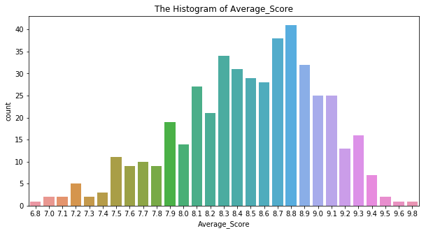

```python
fig,ax=pyplot.subplots(figsize=(10,5))
sns.countplot(x="Average_Score",data=avg_score)
plt.title("The Histogram of Average_Score")
plt.show()
```

The plots show that the most of Hotels' average score in the range of 8.0 and 9.1. And the average score for hotels is distributed with mean=8.411583 and sd=0.528129.

### 2.3.3 Reviewer_Nationality

```python
Hotel.Reviewer_Nationality.describe()
```

```
count              59413
unique               200
top       United Kingdom
freq               16774
Name: Reviewer_Nationality, dtype: object
```

```
Text(0,0.5,'Country')
```

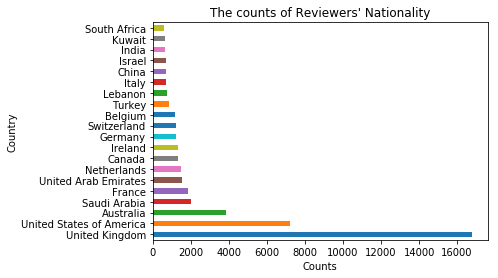

```python
reviewers=Hotel.Reviewer_Nationality.value_counts()
reviewers[:20].plot(kind='barh')
plt.title("The counts of Reviewers' Nationality")
plt.xlabel("Counts")
plt.ylabel("Country")
```

### 2.3.4 Review_Date

```python
Hotel.Review_Date.describe()
```

```
count                          59413
unique                           731
top       2016-09-15 00:00:00.000000
freq                             250
Name: Review_Date, dtype: object
```

In the 731 unique dates, we find most of reviews are give on 2016-09-15.

```python
month_counts=Hotel.month.value_counts()
month_counts=pd.DataFrame(month_counts)
month_counts=month_counts.iloc[[7,9,8,6,4,5,1,0,2,3,10,11],]
month_counts
```

|  | month |
| --- | --- |
| Jan | 4287 |
| Feb | 3904 |
| Mar | 4228 |
| Apr | 4900 |
| May | 5442 |
| Jun | 5057 |
| Jul | 6142 |
| Aug | 6488 |
| Sep | 5707 |
| Oct | 5510 |
| Nov | 3890 |
| Dec | 3858 |

```
Text(0,0.5,'Month')
```

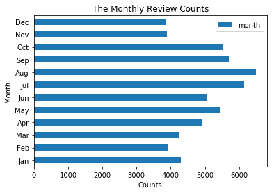

```python
fig1=month_counts.plot(kind="barh")
fig1.set_title("The Monthly Review Counts")
fig1.set_xlabel("Counts")
fig1.set_ylabel("Month")
```

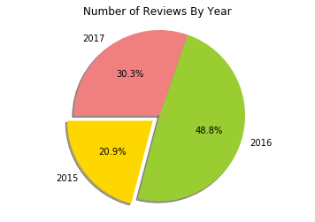

```python
Hotel_by_Year = Hotel.groupby('year').count().iloc[:,0]
Hotel_by_Year.name = 'Count'

# Data to plot
labels = '2015', '2016', '2017'
sizes = Hotel_by_Year.tolist()
colors = ['gold', 'yellowgreen', 'lightcoral']
explode = (0.1, 0, 0)  # explode 1st slice

# Plot
plt.pie(sizes, explode=explode, labels=labels, colors=colors,
        autopct='%1.1f%%', shadow=True, startangle=180)
plt.title('Number of Reviews By Year')
plt.axis('equal')
plt.show()
```

Based on these bar plots, it is obvious that the high season for tourism is on July,Aug,Sep,and Oct. And also, we see that year 2016 had the most number of reviews (48.8%) and 2015 had the least (20.9%)

### 2.3.5 Reviewer_Score

```python
Hotel.Reviewer_Score.describe()
```

```
count    59413.000000
mean         8.424395
std          1.652847
min          2.500000
25%          7.500000
50%          8.800000
75%          9.600000
max         10.000000
Name: Reviewer_Score, dtype: float64
```

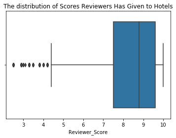

```python
sns.boxplot(Hotel.Reviewer_Score)
plt.title("The distribution of Scores Reviewers Has Given to Hotels")
plt.show()
```

### 2.3.6 Total_Number_of_Reviews_Reviewer_Has_Given

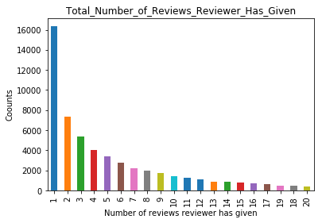

```python
Hotel.Total_Number_of_Reviews_Reviewer_Has_Given.value_counts()[0:20].plot(kind="bar")
plt.title("Total_Number_of_Reviews_Reviewer_Has_Given")
plt.xlabel("Number of reviews reviewer has given")
plt.ylabel("Coounts")
plt.show()
```

```python
Hotel.Total_Number_of_Reviews_Reviewer_Has_Given.value_counts()[0:5]
```

```
1    16363
2     7375
3     5357
4     4046
5     3377
Name: Total_Number_of_Reviews_Reviewer_Has_Given, dtype: int64
```

We can know that 27.54% (16363/59413) of user's reviewed for the first time.

### 2.3.7 Word Could Image for Positive/Negative reviews.

```python
q = """

    SELECT Positive_Review
    FROM Hotel

    WHERE TRIM(Positive_Review) != 'No Positive' AND TRIM(Positive_Review) IS NOT NULL
    AND TRIM(Positive_Review) NOT IN ('N/A', 'NA', 'None', 'N A', 'na', 'n/a')


"""
positives = pd.DataFrame(sqldf(q))
positives.head(5)
q = """

    SELECT Negative_Review
    FROM Hotel

    WHERE TRIM(Negative_Review) != 'No Negative' AND TRIM(Negative_Review) IS NOT NULL
    AND TRIM(Negative_Review) NOT IN ('N/A', 'NA', 'None', 'N A', 'na', 'n/a')

"""


negatives = pd.DataFrame(sqldf(q))
negatives.head(5)
```

|  | Negative_Review |
| --- | --- |
| 0 | Not only did the staff on arrival ask to copy... |
| 1 | The sauna is a wonderfull addition it s a sha... |
| 2 | They have maintenance and I couldn t enjoy th... |
| 3 | Reception not impressive building was under c... |
| 4 | lift wasn t working to 6th floor as under mai... |

```python
def df_to_sarray(df):

    v = df.values
    cols = df.columns

    if six.PY2:

        types = [(cols[i].encode(), df[k].dtype.type) for (i, k) in enumerate(cols)]

    else:

        types = [(cols[i], df[k].dtype.type) for (i, k) in enumerate(cols)]

    dtype = np.dtype(types)

    z = np.zeros(v.shape[0], dtype)

    for (i, k) in enumerate(z.dtype.names):

        z[k] = v[:, i]

    return z

negatives_new = df_to_sarray(negatives.reset_index())
positives_new = df_to_sarray(positives.reset_index())
```

```python
negatives_new = pd.DataFrame(negatives_new)
negatives_new.to_csv('negatives_worldcloud.csv', header = None, index = None)

positives_new = pd.DataFrame(positives_new)
positives_new.to_csv('positives_worldcloud.csv', header = None, index = None)
```

We believe it is useful to create a word visualization of the most common words people are using to write their reviews. Through this way we may see the behavior of individuals and how they express their feelings when they write reviews in Paris, France.

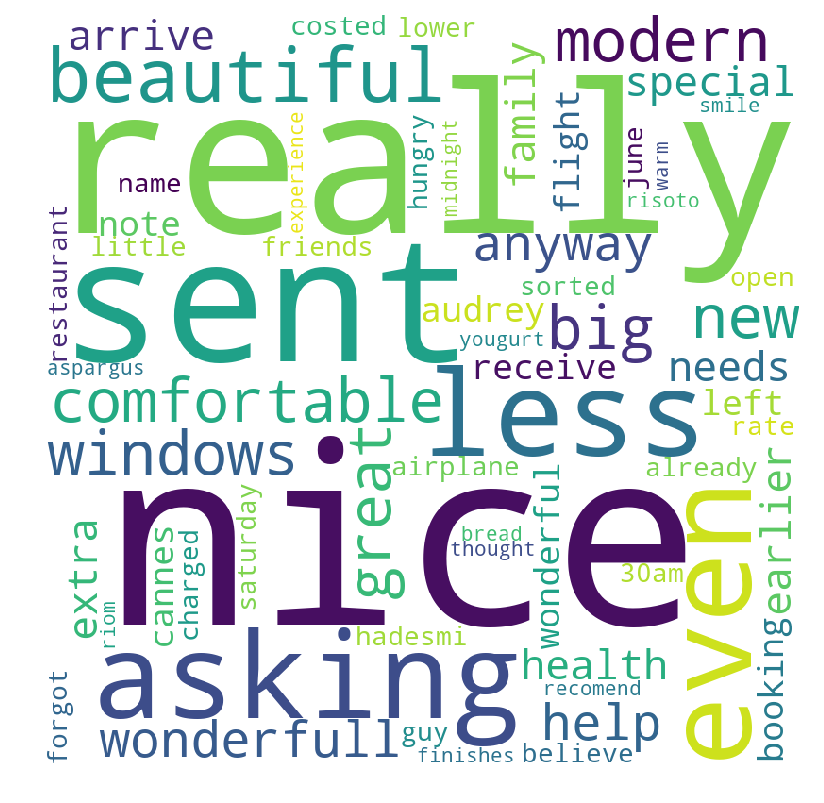

```python
df = pd.read_csv(r"positives_worldcloud.csv", encoding = "latin-1")

comment_words = ' '
stopwords = set(STOPWORDS)
more = ['hotel', 'staff', 'bed', 'service', 'reservation', 'reception', 'day', 'stay', 'area', 'night', 'pro', 'metro',
      'neighbourhood', 'situated', 'Meir', 'Positive_Review', 'class', 'arrived', 'room', 'rooms',
      'desk', 'gar', 'amenities', 'late', 'street', 'eiffel', 'close', 'everything', 'property', 've', 'mention',
      'Irene', 'Receptionist', 'minutes', 'professional', 'wi', 'keeping', 'simply', 'second', 'house', 'bedroom',
      'wanted', 'located', 'comforta', 'better', 'shower', 'find', 'classic', 'time', 'asked', 'beds',
      'change', 'st', 'therooms', 'more', 'hard', 'paid', 'worth', 'bit', 'didn', 'ver', 'TV', 'kind', 'lobby', 'almost', 'well'
      ,'Paris', 'ok', 'one', 'size', 'nothing', 'facilities', 'bathroom', 'first', 'stars', 'clients', 'problem', 'expect',
       'monhotel', 'minute', 'email', 'managed', 'asparagus', 'went', 'prior', 'last', 'entering', 'dealt',
       'maybe', 'details', 'card', 'copy', 'ask', 'back', 'arrival', 'credit', 'noted']

for part in range(len(more)):
    stopwords.add(more[part])

# iterate through the csv file
for val in df:

    # typecaste each val to string
    val = str(val)

    # split the value
    tokens = val.split()

    # Converts each token into lowercase
    for i in range(len(tokens)):
        tokens[i] = tokens[i].lower()

    for words in tokens:
        comment_words = comment_words + words + ' '


wordcloud = WordCloud(width = 800, height = 800,
                background_color ='white',
                stopwords = stopwords,
                min_font_size = 10).generate(comment_words)

# plot the WordCloud image
plt.figure(figsize = (8, 8), facecolor = None)
plt.imshow(wordcloud)
plt.axis("off")
plt.tight_layout(pad = 0)

plt.show()
```

We see from here that people are using many different adjectives to describe their positive experiences. We also remove a list of common english stopwords and create our list of stopwords in addition to that so that we filter words that would not provide us any insight. Two words that people commonly use is : windows, costed, and arrive. For example, many of the reviews could be mentioning cost of the hotel as a factor in their wonderful experience, or their experience with the staff on arrival.

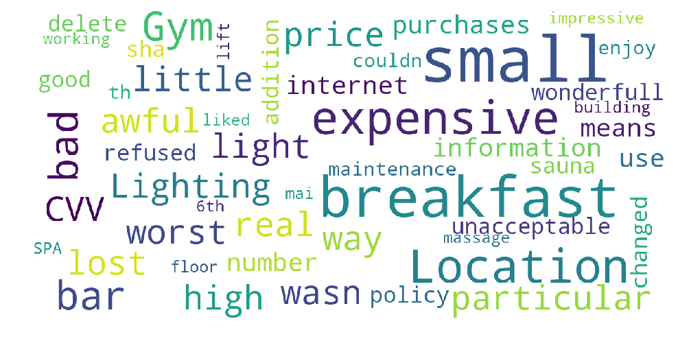

```python
df = pd.read_csv(r"negatives_worldcloud.csv", encoding = "latin-1")

comment_words = ' '
stopwords = set(STOPWORDS)

more = ['hotel', 'staff', 'bed', 'service', 'reservation', 'reception', 'day', 'stay', 'area', 'night', 'pro', 'metro',
      'neighbourhood', 'situated', 'Meir', 'Positive_Review', 'class', 'arrived', 'room', 'rooms',
      'desk', 'gar', 'amenities', 'late', 'street', 'eiffel', 'close', 'everything', 'property', 've', 'mention',
      'Irene', 'Receptionist', 'minutes', 'professional', 'wi', 'keeping', 'simply', 'second', 'house', 'bedroom',
      'wanted', 'located', 'comforta', 'better', 'shower', 'find', 'classic', 'time', 'asked', 'beds',
      'change', 'st', 'therooms', 'more', 'hard', 'paid', 'worth', 'bit', 'didn', 'ver', 'TV', 'kind', 'lobby', 'almost', 'well'
      ,'Paris', 'ok', 'one', 'size', 'nothing', 'facilities', 'bathroom', 'first', 'stars', 'clients', 'problem', 'expect',
       'monhotel', 'minute', 'email', 'managed', 'asparagus', 'went', 'prior', 'last', 'entering', 'dealt',
       'maybe', 'details', 'card', 'copy', 'ask', 'back', 'arrival', 'credit', 'noted']


for part in range(len(more)):


    stopwords.add(more[part])

def show_wordcloud(data, title = None):
    wordcloud = WordCloud(
        background_color = 'white',
        stopwords = stopwords,
        max_words = 50,
        max_font_size = 40,
        scale = 3,
        random_state = 1
    ).generate(str(data))

    fig = plt.figure(1, figsize = (12, 12))
    plt.axis('off')
    if title:
        fig.suptitle(title, fontsize = 20)
        fig.subplots_adjust(top = 2.3)

    plt.imshow(wordcloud)
    plt.show()


if __name__ == '__main__':

    show_wordcloud(df)
```

We see here that words such as the internet and lighting of the hotel are commonly writen in the negative review section. People may have high expectations for WIFI, for example, or the lighting of their room during day time.

### 2.3.8 Analysis of Paris Attacks (2015) Impacts

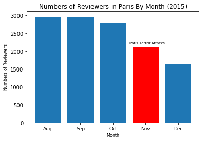

```python
from datetime import datetime

monthList = Hotel[Hotel.year == 2015].month.unique().tolist()

monthList = sorted(monthList, key=lambda day: datetime.strptime(day, "%b"))

label = Hotel[Hotel.year == 2015].groupby('month').count().iloc[:,0]
label = label.reindex(['Aug','Sep','Oct','Nov','Dec'])

index = np.arange(len(monthList))
hotel_graph = plt.bar(monthList, label)
plt.xlabel('Month', fontsize=8)
plt.ylabel('Numbers of Reviewers', fontsize=8)
plt.xticks(index, monthList, fontsize=9)
plt.title('Numbers of Reviewers in Paris By Month (2015)')
plt.text(x = 2.5 , y = 2200, s = 'Paris Terror Attacks', size = 7)
hotel_graph[3].set_color('r')
plt.show()
```

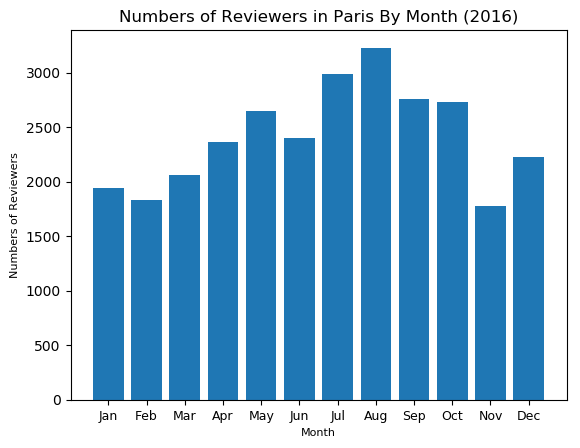

```python
monthList = Hotel[Hotel.year == 2016].month.unique().tolist()
monthList = sorted(monthList, key=lambda day: datetime.strptime(day, "%b"))

label = Hotel[Hotel.year == 2016].groupby('month').count().iloc[:,0]
label = label.reindex(['Jan','Feb','Mar','Apr','May','Jun','Jul','Aug','Sep','Oct','Nov','Dec'])

index = np.arange(len(monthList))
hotel_graph = plt.bar(index, label)

plt.xlabel('Month', fontsize=8)
plt.ylabel('Numbers of Reviewers', fontsize=8)
plt.xticks(index, monthList, fontsize=9)
plt.title('Numbers of Reviewers in Paris By Month (2016)')
plt.show()
```

We see that when we look at the following year, 2016, during the first few months the effect of the Paris attacks on the number of reviewers on Booking.com does continue. Eventually, the number of reviewers across months of April and beyond do begin to return to normal again.

### 2.4 Unusual features or outliers present in the data

```python
def Classes(df):

    for col in df:

        print(col)
        print(type(df[col].iat[0]))
        print('\n')

#Classes(Hotel)
```

```python
numerics = ['int16', 'int32', 'int64', 'float16', 'float32', 'float64']

hotel_numeric = Hotel.select_dtypes(include = numerics)

Q1 = hotel_numeric.quantile(0.25)
Q3 = hotel_numeric.quantile(0.75)

IQR = Q3 - Q1

outliers = ((hotel_numeric < (Q1 - 1.5 * IQR)) | (hotel_numeric > (Q3 + 1.5 * IQR))).sum()
outliers = pd.DataFrame(outliers)
outliers = outliers.reset_index()
outliers.columns = ['Column', 'Number_of_Outliers']
outliers = outliers.drop(outliers.index[[7,8,9]])
outliers
```

|  | Column | Number_of_Outliers |
| --- | --- | --- |
| 0 | Additional_Number_of_Scoring | 6552 |
| 1 | Average_Score | 123 |
| 2 | Review_Total_Negative_Word_Counts | 4172 |
| 3 | Total_Number_of_Reviews | 5470 |
| 4 | Review_Total_Positive_Word_Counts | 4105 |
| 5 | Total_Number_of_Reviews_Reviewer_Has_Given | 4727 |
| 6 | Reviewer_Score | 2035 |
| 10 | year | 0 |
| 11 | day | 0 |

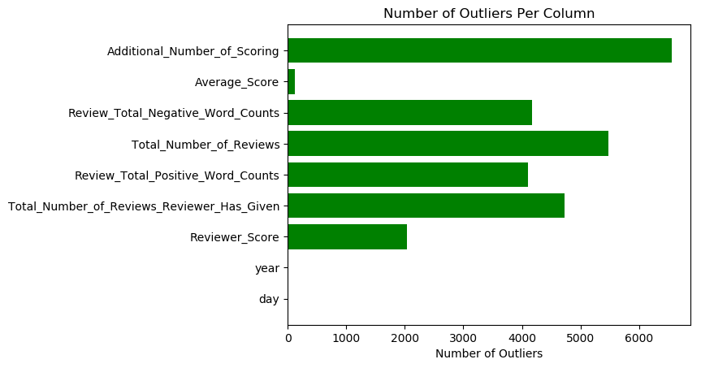

```python
plt.rcdefaults()
fig, ax = plt.subplots()
y_pos = np.arange(len(outliers['Column']))

number = outliers['Number_of_Outliers']

ax.barh(y_pos, number, align='center',
        color='green', ecolor='black')

ax.set_yticks(y_pos)

ax.set_yticklabels(outliers['Column'])

ax.invert_yaxis()  # labels read top-to-bottom
ax.set_xlabel('Number of Outliers')
ax.set_title('Number of Outliers Per Column')

plt.show()
```

The variable "Additional_Numeber_of_Scoring" has the largest number of outliers.

### 2.5 Potential relationships

### 2.5.a Two-way table and side-by-side bar chart for relationships between categorical data

#### What does the reviewers' attitude look like based on the Top 10 reviewed hotels?

Due to our Hotel data having limited categorical variables, we create a new column(Attitude) which has two values: GOOD and BAD based on the ratio of "Review_Total_Positive_Word_Counts" & "Review_Total_Negative_Word_Counts". If the ratio is greater than 1, their reviews is more positive. If the ratio is less than 1, their reviews is more negative. And then, we can find two-way table between "Attitude" & "Hotel_Name" to see the what the reviewer attitude looks like for the top 10 reviewed hotels.

```python
attitude=Hotel.groupby(["Hotel_Name","Attitude"]).Attitude.count().unstack()
attitude=pd.DataFrame(attitude)
attitude.head(10)
```

| Attitude Hotel_Name | BAD | GOOD |
| --- | --- | --- |
| 1K Hotel | 88 | 60 |
| 9Hotel Republique | 69 | 114 |
| A La Villa Madame | 11 | 30 |
| AC Hotel Paris Porte Maillot by Marriott | 28 | 47 |
| Acad mie H tel Saint Germain | 81 | 174 |
| Amarante Beau Manoir | 93 | 66 |
| Amarante Champs Elys es | 49 | 53 |
| Amp re | 52 | 120 |
| Arioso | 15 | 23 |
| Artus Hotel by MH | 13 | 45 |

We choose the top 10 most reviewed hotels to see the situation of reviewer_attitude

```python
Hotel.Hotel_Name.value_counts()[:10]
```

```
Mercure Paris Terminus Nord           1459
Holiday Inn Paris Gare de l Est       1129
Hyatt Regency Paris Etoile             874
Pullman Paris Tour Eiffel              846
Mercure Paris Centre Tour Eiffel       770
Saint James Albany Paris Hotel Spa     700
Novotel Paris Gare De Lyon             566
Novotel Paris Les Halles               523
Novotel Paris Centre Tour Eiffel       497
Le Parisis Paris Tour Eiffel           428
Name: Hotel_Name, dtype: int64
```

[figure not shown]

```python
attitude.loc[["Mercure Paris Terminus Nord",
              "Holiday Inn Paris Gare de l Est","Hyatt Regency Paris Etoile",
             "Pullman Paris Tour Eiffel","Mercure Paris Centre Tour Eiffel",
             "Saint James Albany Paris Hotel Spa",
             "Novotel Paris Gare De Lyon",
             "Novotel Paris Les Halles",
             "Novotel Paris Centre Tour Eiffel",
              "Le Parisis Paris Tour Eiffel"],["BAD","GOOD"]].plot.barh()
plt.title("The reviewers' attitude for the top 10 reviewed hotels in Paris")
plt.show()
```

Based on this side-by-side bar plot, we can find that the number of bad review words for "Mercure Paris Terminus Nord" is equivalent to the number of good review words. However, the hotel "Hyatt Regency Paris Eroile" has a not good proportion of positive review words counts. In fact it is the only hotel in here that has a far greater number of "Bad" then "Good". Its negative words count is obviously greater than the positive review words. It is a little surprising that such a reputable hotel franchise like Hyatt would have not just many reviews, but more of them being classified as "Bad".

#### For each of three reasons of being hotels, are solo reviewers more?

```python
solo=Hotel.groupby(["Reason","Solo"]).Solo.count().unstack()
solo=pd.DataFrame(solo)
solo.head()
```

| Solo Reason | No | Yes |
| --- | --- | --- |
| Business | 2955 | 6707 |
| Leisure | 42940 | 5482 |
| NOT STATED | 935 | 394 |

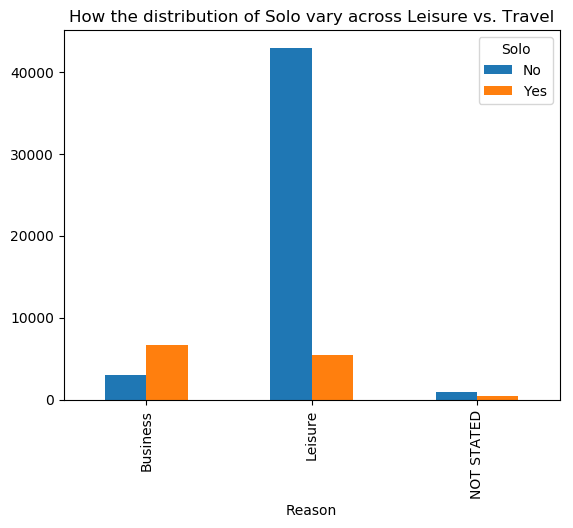

```python
solo.plot.bar()
plt.title("How the distribution of Solo vary across Leisure vs. Travel")
plt.show()
```

From the barplot, we can conclude that more people tends to travel solo for business visit than for leisure trip.Lastly, another interesting thing is that most of reviewers who are traveling to hotels on a leisure purpose are not solo traveling.

### 2.5.b Scatter plots for relationships between numeric data

#### Is there any relationship between the number of valid scores hotel has and the total number of valid reviews hotel has?

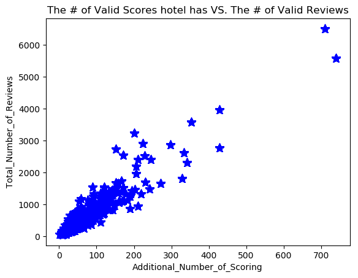

```python
plt.scatter(Hotel["Additional_Number_of_Scoring"],Hotel["Total_Number_of_Reviews"],s=100,c="blue",marker="*")
plt.title("The # of Valid Scores hotel has VS. The # of Valid Reviews")
plt.xlabel("Additional_Number_of_Scoring")
plt.ylabel("Total_Number_of_Reviews")
plt.show()
```

This plots shows that there is a positive linear relationship between the number of valid scores (service only) and the number of total valid reviews hotel has (including review texts). The more number of valid scores regarding just service, this corresponds to an increase as well in the amount of reviews that do include text.

#### How the positive word counts effect the reviewer scores for the reviewers who come from different continent?

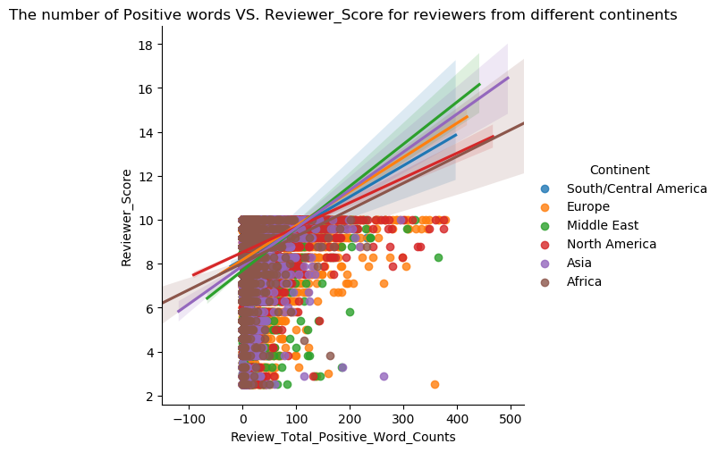

```python
sns.lmplot(x="Review_Total_Positive_Word_Counts",y="Reviewer_Score",hue="Continent",data=Hotel)
plt.title("The number of Positive words VS. Reviewer_Score for reviewers from different continents")
plt.show()
```

It basically means that Asians and Milddle Eastern people speak up more for what they believe in. It will very much turn into positive reviews compared to other countries. If they wrote a lot of words in their positive reivew, it must mean they rate it well because the slopes of green and purple lines are greater than others. So, this graph shows that the trend of Middle East and Asia lines is more positive compare to other continents.

Now we want to explore the relationship between Additional number of scoring and the Average score of the hotel

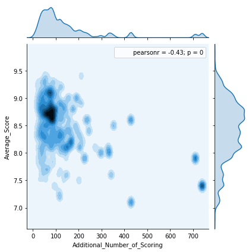

```python
sns.jointplot(x="Additional_Number_of_Scoring",y="Average_Score",data=Hotel,kind="kde")
```

The relationship here shows that as a hotel has more counts for Additional Number of Scoring, the Average Score of the hotel decreases and there may be an open-ended way to interpret this. If there are many reviewers that are only rating based on service and are not writing anything, they on average may be dissatisfied with the hotel enough that they no longer desire to express their opinion.

### 2.5.c Boxplots for relationships between numeric and categorical data

#### Is there difference between reviewer scores among the different continent?

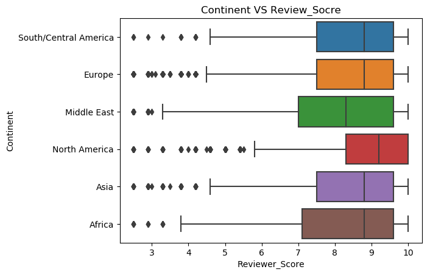

```python
sns.boxplot(y="Continent",x="Reviewer_Score",data=Hotel)
plt.title("Continent VS Review_Socre")
plt.show()
```

From the boxplot, we can know that the reviewers who come from North America will give a relatively high scores for hotels. Reviewers from Middle East rated hotels on average with lower scores (however the boxplot indicates that their scores can deviate a lot) In general, the mean of reviewer socres is between 8.0 to 9.0 among the different continents. It is interesting to find out why the median value of Reviewer_Score is the worst for the Middle East region. It may be due to cultural differences between the two countries or higher expectations from this group of people, but we cannot know for sure.

#### Is there difference between reviewer scores among the different reasons over the six continents?

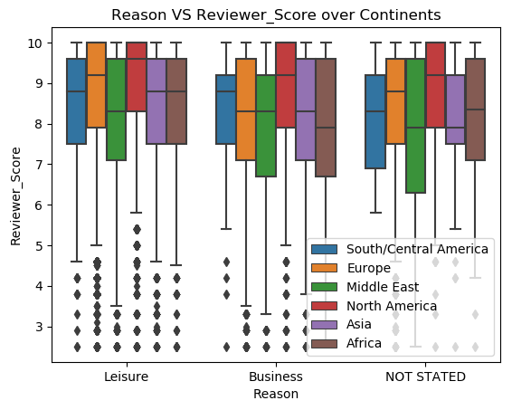

```python
sns.boxplot(x="Reason",y="Reviewer_Score",hue="Continent",data=Hotel)
plt.legend(loc=4)
plt.title("Reason VS Reviewer_Score over Continents")
plt.show()
```

## 3. Data Modeling

### 3.1 Anova Models

```python
import statsmodels.api as sm
from statsmodels.formula.api import ols
import scipy.stats as stats

q = """
        SELECT Reviewer_Score, Continent
        FROM Hotel


"""
pre_anova = pd.DataFrame(sqldf(q))
mod = ols('Reviewer_Score ~ Continent',
                data = pre_anova).fit()

aov_table = sm.stats.anova_lm(mod, typ = 2)
print(aov_table)
```

```
                  sum_sq       df           F         PR(>F)
Continent    3482.294257      5.0  260.502964  2.006540e-276
Residual   158825.567146  59407.0         NaN            NaN
```

When we construct a one-way anova model for analysis of variance between the mean Review Score by Continent, we get a highly significant F value of 260. This indicates that at least one of the pairwise mean comparisons are signficantly different from each other. But we do not know which ones, so we proceed with a Tukey's multiple comparison test.

```python
from statsmodels.stats.multicomp import pairwise_tukeyhsd
from statsmodels.stats.multicomp import MultiComparison

mc = MultiComparison(pre_anova['Reviewer_Score'], pre_anova['Continent'])
result = mc.tukeyhsd()

print(result)
print(mc.groupsunique)
```

```
         Multiple Comparison of Means - Tukey HSD,FWER=0.05
===================================================================
    group1            group2        meandiff  lower   upper  reject
-------------------------------------------------------------------
    Africa             Asia         -0.0345  -0.1915  0.1224 False
    Africa            Europe         0.2536   0.1108  0.3964  True
    Africa         Middle East      -0.2832  -0.4328 -0.1336  True
    Africa        North America      0.5613   0.412   0.7106  True
    Africa    South/Central America  0.181   -0.0494  0.4114 False
     Asia             Europe         0.2882   0.2144  0.3619  True
     Asia          Middle East      -0.2487  -0.3348 -0.1625  True
     Asia         North America      0.5958   0.5101  0.6815  True
     Asia     South/Central America  0.2155   0.0203  0.4108  True
    Europe         Middle East      -0.5368  -0.5933 -0.4803  True
    Europe        North America      0.3077   0.2519  0.3634  True
    Europe    South/Central America -0.0726  -0.2567  0.1115 False
 Middle East      North America      0.8445   0.7731  0.9159  True
 Middle East  South/Central America  0.4642   0.2748  0.6537  True
North America South/Central America -0.3803  -0.5695 -0.1911  True
-------------------------------------------------------------------
['Africa' 'Asia' 'Europe' 'Middle East' 'North America'
 'South/Central America']
```

The result of the multiple comparison test is that 3 pairwise mean comparisons of Africa to Asia, Africa to Central America, and Europe to Central America are not significantly different because their confidence intervals contain 0 in them.

### 3.2 Tree based methods for classification

```python
import numpy as np
from sklearn import datasets

# decision tree
from sklearn.tree import DecisionTreeClassifier


Hotel.groupby(['Season','Reason']).count()
```

| Season | Reason | Hotel_Address | Additional_Number_of_Scoring | Review_Date | Average_Score | Hotel_Name | Reviewer_Nationality | Negative_Review | Review_Total_Negative_Word_Counts | Total_Number_of_Reviews | Positive_Review | ... | Tags | days_since_review | lat | lng | year | month | day | Attitude | Continent | Solo |
| --- | --- | --- | --- | --- | --- | --- | --- | --- | --- | --- | --- | --- | --- | --- | --- | --- | --- | --- | --- | --- | --- | --- |
| Fall | Business | 1950 | 1950 | 1950 | 1950 | 1950 | 1950 | 1950 | 1950 | 1950 | 1950 | ... | 1950 | 1950 | 1950 | 1950 | 1950 | 1950 | 1950 | 1950 | 1950 | 1950 |
|  | Leisure | 9027 | 9027 | 9027 | 9027 | 9027 | 9027 | 9027 | 9027 | 9027 | 9027 | ... | 9027 | 9027 | 9027 | 9027 | 9027 | 9027 | 9027 | 9027 | 9027 | 9027 |
|  | NOT STATED | 240 | 240 | 240 | 240 | 240 | 240 | 240 | 240 | 240 | 240 | ... | 240 | 240 | 240 | 240 | 240 | 240 | 240 | 240 | 240 | 240 |
| Spring | Business | 2479 | 2479 | 2479 | 2479 | 2479 | 2479 | 2479 | 2479 | 2479 | 2479 | ... | 2479 | 2479 | 2479 | 2479 | 2479 | 2479 | 2479 | 2479 | 2479 | 2479 |
|  | Leisure | 11794 | 11794 | 11794 | 11794 | 11794 | 11794 | 11794 | 11794 | 11794 | 11794 | ... | 11794 | 11794 | 11794 | 11794 | 11794 | 11794 | 11794 | 11794 | 11794 | 11794 |
|  | NOT STATED | 297 | 297 | 297 | 297 | 297 | 297 | 297 | 297 | 297 | 297 | ... | 297 | 297 | 297 | 297 | 297 | 297 | 297 | 297 | 297 | 297 |
| Summer | Business | 1894 | 1894 | 1894 | 1894 | 1894 | 1894 | 1894 | 1894 | 1894 | 1894 | ... | 1894 | 1894 | 1894 | 1894 | 1894 | 1894 | 1894 | 1894 | 1894 | 1894 |
|  | Leisure | 15385 | 15385 | 15385 | 15385 | 15385 | 15385 | 15385 | 15385 | 15385 | 15385 | ... | 15385 | 15385 | 15385 | 15385 | 15385 | 15385 | 15385 | 15385 | 15385 | 15385 |
|  | NOT STATED | 408 | 408 | 408 | 408 | 408 | 408 | 408 | 408 | 408 | 408 | ... | 408 | 408 | 408 | 408 | 408 | 408 | 408 | 408 | 408 | 408 |
| Winter | Business | 3339 | 3339 | 3339 | 3339 | 3339 | 3339 | 3339 | 3339 | 3339 | 3339 | ... | 3339 | 3339 | 3339 | 3339 | 3339 | 3339 | 3339 | 3339 | 3339 | 3339 |
|  | Leisure | 12216 | 12216 | 12216 | 12216 | 12216 | 12216 | 12216 | 12216 | 12216 | 12216 | ... | 12216 | 12216 | 12216 | 12216 | 12216 | 12216 | 12216 | 12216 | 12216 | 12216 |
|  | NOT STATED | 384 | 384 | 384 | 384 | 384 | 384 | 384 | 384 | 384 | 384 | ... | 384 | 384 | 384 | 384 | 384 | 384 | 384 | 384 | 384 | 384 |

12 rows × 23 columns

```python
from sklearn.metrics import confusion_matrix
from sklearn.cross_validation import train_test_split
from sklearn.tree import DecisionTreeClassifier
from sklearn.metrics import accuracy_score
from sklearn.metrics import classification_report, confusion_matrix

Continent_dict = { 'South/Central America':1, 'Europe':2,
              'Middle East':3, 'North America':4,'Asia':5,
              'Africa':6 }
Solo_dict = { 'Yes':1, 'No':0 }
Season_dict = { 'Fall':1, 'Winter':2, 'Spring':3, 'Summer':4 }
month_dict = { 'Jan':1, 'Feb':2, 'Mar':3, 'Apr':4, 'May':5, 'Jun':6, 'Jul':7, 'Aug':8,
     'Sep':9, 'Oct':10, 'Nov':11, 'Dec':12 }

new_df = Hotel.loc[:,['Reason','Continent','Solo','Season','month']]
new_df['Continent'] = new_df['Continent'].map(Continent_dict)
new_df['Solo'] = new_df['Solo'].map(Solo_dict)
new_df['Season'] = new_df['Season'].map(Season_dict)
new_df['month'] = new_df['month'].map(month_dict)
filtered_df = new_df[new_df.Reason != 'NOT STATED']

# We removed NOT STATED!
```

```python
filtered_df.head()
```

|  | Reason | Continent | Solo | Season | month |
| --- | --- | --- | --- | --- | --- |
| 0 | Leisure | 1 | 0 | 4 | 6 |
| 1 | Business | 2 | 1 | 3 | 4 |
| 2 | Leisure | 2 | 0 | 3 | 4 |
| 3 | Business | 2 | 1 | 2 | 11 |
| 4 | Business | 3 | 1 | 4 | 8 |

Above is the data that we will use for a decision tree model, predicting the variable : Reason. The reason we include these variables is as follows : We first exhibited a relationship between Season containing different proportions of reviewers that traveled for purposes of leisure and business. In addition, when people travel for purposes of leisure, we found they they tend to travel in groups rather than alone. In addition, we saw differences in people that travel for leisure and business between months of the year. In addition, we believe it is worth including the Continent of origin for the reviewer because some nationalities have differences in culture and traveling style and we would like to include this when we want to classify as Leisure of Business.

```python
# Function to split the dataset
def splitData(data):

    X = data.values[:, 1:5]
    Y = data.values[:, 0]

    X_train, X_test, y_train, y_test = train_test_split(
    X, Y, test_size = 0.3, random_state = 139)

    return X, Y, X_train, X_test, y_train, y_test

def entropy_method(X_train, X_test, y_train):

    entropy_lf = DecisionTreeClassifier(
            criterion = "entropy", random_state = 139,
            max_depth = 5, min_samples_leaf = 5)

    entropy_lf.fit(X_train, y_train)

    return entropy_lf

# Function to make predictions
def prediction(X_test, lf):
    y_pred = lf.predict(X_test)
    return y_pred

def accuracy_results(y_test, y_pred):

    print ("Accuracy:",
    accuracy_score(y_test,y_pred)*100)

    print("Report : ",
    classification_report(y_test, y_pred))

def decision_tree():

    X, Y, X_train, X_test, y_train, y_test = splitdataset(filtered_df)
    clf_entropy = entropy_method(X_train, X_test, y_train)

    y_pred_entropy = prediction(X_test, clf_entropy)
    accuracy_results(y_test, y_pred_entropy)

    return clf_entropy


decision_tree()
```

```
Accuracy: 86.54309652243774
Report :               precision    recall  f1-score   support

   Business       0.63      0.50      0.56      2944
    Leisure       0.90      0.94      0.92     14482

avg / total       0.86      0.87      0.86     17426
```

```
DecisionTreeClassifier(class_weight=None, criterion='entropy', max_depth=5,
            max_features=None, max_leaf_nodes=None,
            min_impurity_decrease=0.0, min_impurity_split=None,
            min_samples_leaf=5, min_samples_split=2,
            min_weight_fraction_leaf=0.0, presort=False, random_state=139,
            splitter='best')
```

Our Decision tree model predicted the category of reason : business or leisure with 86.54% total accuracy by our confusion matrix! We have done better than guessing. For business, we correctly labeled the reason 63% of the time, but for leisure, we correctly labeled the reason 90% of the time.

### 3.3 KNN Classification

```
[[ 1287  1652]
 [  900 13587]]
             precision    recall  f1-score   support

   Business       0.59      0.44      0.50      2939
    Leisure       0.89      0.94      0.91     14487

avg / total       0.84      0.85      0.84     17426
```

```
Text(0,0.5,'Mean Errors')
```

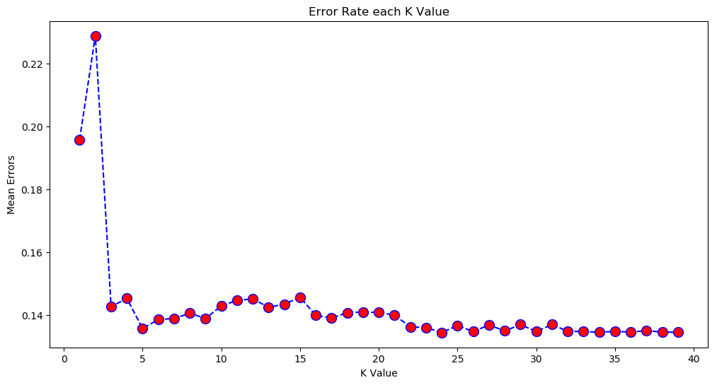

```python
from sklearn.neighbors import KNeighborsClassifier
y = filtered_df.Reason
X = filtered_df.drop('Reason', axis=1)
X_train, X_test, y_train, y_test = train_test_split(X, y,test_size=0.3)

#Here we consider the test size to be 30% and training size to be 70%.

classifiers = KNeighborsClassifier(n_neighbors=5)
classifiers.fit(X_train, y_train)



y_pred = classifiers.predict(X_test)

print(confusion_matrix(y_test, y_pred))
print(classification_report(y_test, y_pred))


error_values = []
for i in range(1, 40):
    knn = KNeighborsClassifier(n_neighbors=i)
    knn.fit(X_train, y_train)
    pred1 = knn.predict(X_test)
    error_values.append(np.mean(pred1 != y_test))

plt.figure(figsize=(12, 6))
plt.plot(range(1, 40), error, color='blue', linestyle='dashed', marker='o',
         markerfacecolor='red', markersize=10)
plt.title('Error Rate each K Value')
plt.xlabel('K Value')
plt.ylabel('Mean Errors')
```

We see from the confusion matrix for KNN classification that the accuracy rate is 85.356 %, and the accuracy rate for Decision Trees is 86.543%. Therefore, we determine that Tree based methods for this data, predicting leisure or business, is a better classifier than KNN. However, if you select a particular K value for KNN classification of >=25 then you may potentially have a better classifier than Decision trees would give.